# R Notebook

#0-SETTING UP DATA; COMBINING TWO DATASETS

```r
#0-SETTING UP DATA; COMBINING TWO DATASETS
library(tidyverse)
library(dplyr)
library(fivethirtyeight)
data(drinks)
data(cousin_marriage)
cousin_marriage
```

| country | percent |
| --- | --- |
| Burkina Faso | 65.8 |
| Kuwait | 51.7 |
| Nigeria | 51.2 |
| Pakistan | 51.0 |
| Sudan | 50.4 |
| Kyrgyzstan | 45.2 |
| Qatar | 44.5 |
| Bahrain | 44.4 |
| Saudi Arabia | 38.4 |
| Tanzania | 37.8 |

[output cut: 60 more lines]

```r
dranks <- full_join(cousin_marriage, drinks, by="country")
dranks2 <- dranks %>% na.omit
dranks2 %>% mutate(total_serving_of_alcohol = beer_servings+wine_servings+spirit_servings)
```

| country | percent | beer_servings | spirit_servings | wine_servings | total_litres_of_pure_alcohol | total_serving_of_alcohol |
| --- | --- | --- | --- | --- | --- | --- |
| Burkina Faso | 65.8 | 25 | 7 | 7 | 4.3 | 39 |
| Kuwait | 51.7 | 0 | 0 | 0 | 0.0 | 0 |
| Nigeria | 51.2 | 42 | 5 | 2 | 9.1 | 49 |
| Pakistan | 51.0 | 0 | 0 | 0 | 0.0 | 0 |
| Sudan | 50.4 | 8 | 13 | 0 | 1.7 | 21 |
| Kyrgyzstan | 45.2 | 31 | 97 | 6 | 2.4 | 134 |
| Qatar | 44.5 | 1 | 42 | 7 | 0.9 | 50 |
| Bahrain | 44.4 | 42 | 63 | 7 | 2.0 | 112 |
| Saudi Arabia | 38.4 | 0 | 5 | 0 | 0.1 | 5 |
| Tanzania | 37.8 | 36 | 6 | 1 | 5.7 | 43 |

[output cut: 57 more lines]

```r
dranks3 <- dranks2 %>% mutate(total_serving_of_alcohol = beer_servings+wine_servings+spirit_servings)
dranks3 %>% summarize(median(total_serving_of_alcohol))
```

| median(total_serving_of_alcohol) |
| --- |
| 141 |

```r
dranks4<-dranks3 %>%mutate(total_serving_of_alcohol = ntile(total_serving_of_alcohol,n = 2), total_serving_of_alcohol=recode(total_serving_of_alcohol, "low", "high"))
dranks4
```

| country | percent | beer_servings | spirit_servings | wine_servings | total_litres_of_pure_alcohol | total_serving_of_alcohol |
| --- | --- | --- | --- | --- | --- | --- |
| Burkina Faso | 65.8 | 25 | 7 | 7 | 4.3 | low |
| Kuwait | 51.7 | 0 | 0 | 0 | 0.0 | low |
| Nigeria | 51.2 | 42 | 5 | 2 | 9.1 | low |
| Pakistan | 51.0 | 0 | 0 | 0 | 0.0 | low |
| Sudan | 50.4 | 8 | 13 | 0 | 1.7 | low |
| Kyrgyzstan | 45.2 | 31 | 97 | 6 | 2.4 | low |
| Qatar | 44.5 | 1 | 42 | 7 | 0.9 | low |
| Bahrain | 44.4 | 42 | 63 | 7 | 2.0 | low |
| Saudi Arabia | 38.4 | 0 | 5 | 0 | 0.1 | low |
| Tanzania | 37.8 | 36 | 6 | 1 | 5.7 | low |

[output cut: 57 more lines]

```r
dranks5<-dranks4 %>%mutate(percent = ntile(percent,n = 2), percent=recode(percent, "low", "high"))
dranks5
```

| country | percent | beer_servings | spirit_servings | wine_servings | total_litres_of_pure_alcohol | total_serving_of_alcohol |
| --- | --- | --- | --- | --- | --- | --- |
| Burkina Faso | high | 25 | 7 | 7 | 4.3 | low |
| Kuwait | high | 0 | 0 | 0 | 0.0 | low |
| Nigeria | high | 42 | 5 | 2 | 9.1 | low |
| Pakistan | high | 0 | 0 | 0 | 0.0 | low |
| Sudan | high | 8 | 13 | 0 | 1.7 | low |
| Kyrgyzstan | high | 31 | 97 | 6 | 2.4 | low |
| Qatar | high | 1 | 42 | 7 | 0.9 | low |
| Bahrain | high | 42 | 63 | 7 | 2.0 | low |
| Saudi Arabia | high | 0 | 5 | 0 | 0.1 | low |
| Tanzania | high | 36 | 6 | 1 | 5.7 | low |

[output cut: 57 more lines]

*I am working with a dataset renamed as ‘dranks’, which is originally two data sets, ‘drinks’ and ‘cousin_marriage’, that I have combined together. The drinks data set contains information on the total servings of different alcohols and the total liters of pure alcohol consumed by different countries. All of these are numeric variables and are presented as ‘beer_servings’ which measures the average number of beer servings per person in each country, ‘wine_servings’ which measures the average number of wine servings per person in each country, ‘spirit_servings’ which measures the average number of spirit servings per person in each country, ‘total_liters_of_pure_alcohol’ which measures the average total liters of pure alcohol per person in each country. I have also created the a new categorical variable, with two categories (high and low), named ‘total_serving_of_alcohol’ which measures the total servings of alcohol per person in each country.The cousin_marriage data set contains information on the percentage of people in the country that engage in some form of cousin marriage. The percentage of cousin marriages per country is given by the numeric variable ‘percent’, which I have also converted to a categorical variable with two categories (high and low). These data sets were acquired from the ‘fivethirtyeight’ package. Overall, there is a total number of 67 observations for each variable.*

#1-MANOVA, ANOVAs, POST-HOC T-TESTs

```r
#1-MANOVA, ANOVAs, POST-HOC T-TESTs
man1<-manova(cbind(beer_servings, spirit_servings, wine_servings)~percent,dranks4)
summary(man1)
```

```
          Df  Pillai approx F num Df den Df    Pr(>F)
percent    1 0.56531    27.31      3     63 1.952e-11 ***
Residuals 65
---
Signif. codes:  0 ‘***’ 0.001 ‘**’ 0.01 ‘*’ 0.05 ‘.’ 0.1 ‘ ’ 1
```

```r
summary.aov(man1)
```

```
 Response beer_servings :
            Df Sum Sq Mean Sq F value    Pr(>F)
percent      1 368672  368672  66.629 1.501e-11 ***
Residuals   65 359656    5533
---
Signif. codes:  0 ‘***’ 0.001 ‘**’ 0.01 ‘*’ 0.05 ‘.’ 0.1 ‘ ’ 1

 Response spirit_servings :
            Df Sum Sq Mean Sq F value   Pr(>F)
percent      1  69197   69197  26.986 2.21e-06 ***
Residuals   65 166673    2564
---
Signif. codes:  0 ‘***’ 0.001 ‘**’ 0.01 ‘*’ 0.05 ‘.’ 0.1 ‘ ’ 1

 Response wine_servings :
            Df Sum Sq Mean Sq F value    Pr(>F)
percent      1 157689  157689  23.017 9.764e-06 ***
Residuals   65 445314    6851
---
Signif. codes:  0 ‘***’ 0.001 ‘**’ 0.01 ‘*’ 0.05 ‘.’ 0.1 ‘ ’ 1
```

```r
pairwise.t.test(dranks5$beer_servings,dranks5$percent, p.adj="none")
```

```
    Pairwise comparisons using t tests with pooled SD

data:  dranks5$beer_servings and dranks5$percent

    high
low 3.1e-15

P value adjustment method: none
```

```r
pairwise.t.test(dranks5$spirit_servings,dranks5$percent, p.adj="none")
```

```
    Pairwise comparisons using t tests with pooled SD

data:  dranks5$spirit_servings and dranks5$percent

    high
low 6.3e-06

P value adjustment method: none
```

```r
pairwise.t.test(dranks5$wine_servings,dranks5$percent, p.adj="none")
```

```
    Pairwise comparisons using t tests with pooled SD

data:  dranks5$wine_servings and dranks5$percent

    high
low 1.5e-06

P value adjustment method: none
```

```r
type1error<- 1-(0.95^7)
type1error
```

```
[1] 0.3016627
```

```r
bonferroni <- 0.05/7
bonferroni
```

```
[1] 0.007142857
```

*A total of 7 tests were carried out. Specifically, one MANOVA, three ANOVAs, and 3 post-hoc T-tests. The probability of at least one type error (if unadjusted) is 0.3016627. The bonferroni correction adjusted the significance level to 0.007142857. Despite this change all seven tests had p-values below this significance level still and therefore it can still be concluded that significant difference does exist.* Briefly discuss some of the MANOVA assumptions and whether or not they are likely to have been met here ###ask whether this paragraph is ok and how to meet assumptions#######################

#2-RANDOMIZATION TEST: MEAN DIFFERENCE

```r
#2-RANDOMIZATION TEST: MEAN DIFFERENCE
dranks5 %>% na.omit
```

| country | percent | beer_servings | spirit_servings | wine_servings | total_litres_of_pure_alcohol | total_serving_of_alcohol |
| --- | --- | --- | --- | --- | --- | --- |
| Burkina Faso | high | 25 | 7 | 7 | 4.3 | low |
| Kuwait | high | 0 | 0 | 0 | 0.0 | low |
| Nigeria | high | 42 | 5 | 2 | 9.1 | low |
| Pakistan | high | 0 | 0 | 0 | 0.0 | low |
| Sudan | high | 8 | 13 | 0 | 1.7 | low |
| Kyrgyzstan | high | 31 | 97 | 6 | 2.4 | low |
| Qatar | high | 1 | 42 | 7 | 0.9 | low |
| Bahrain | high | 42 | 63 | 7 | 2.0 | low |
| Saudi Arabia | high | 0 | 5 | 0 | 0.1 | low |
| Tanzania | high | 36 | 6 | 1 | 5.7 | low |

[output cut: 57 more lines]

```r
set.seed(348)
rand_mean<-vector()
for(i in 1:5000){
new<-data.frame(litres=sample(dranks5$total_litres_of_pure_alcohol),incest=dranks5$percent)
rand_mean[i]<-mean(new[new$incest=="high",]$litres)-mean(new[new$incest =="low",]$litres)}

mean(new[new$incest=="high",]$litres)-mean(new[new$incest=="low",]$litres)
```

```
[1] 2.573262
```

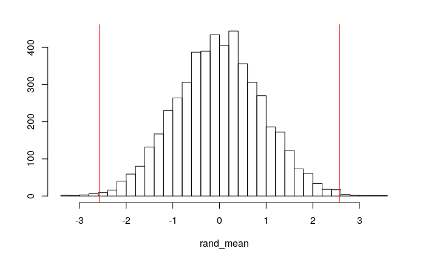

```r
hist(rand_mean,main="",ylab="", breaks =30); abline(v = c(-2.573262, 2.573262),col="red")
```

```r
mean(abs(rand_mean)> 2.573262)
```

```
[1] 0.0044
```

*The null hypothesis is that the mean total litres of alcohol consumed by people in a country is the same for a country with high percentage of cousin marriage vs. for a country with low percentage of cousin marriage, while the alternative hypothesis is that the mean total litres of alcohol consumed by people in a country is different for a country with high percentage of cousin marriage vs. for a country with low percentage of cousin marriage. The results of the randomization test show that the resulting p-value is 0.0044, which is below the significance level of 0.05. Therefore the null hypothesis can be rejected and it can be concluded that the alternative hypothesis is accepted.*

#3-LINEAR REGRESSION MODEL WITH INTERACTION

```r
#3 - HW#7-2.1
library(sandwich)
dranks4
```

[output not shown]

[output cut: 57 more lines]

```r
dranks4$total_litres_of_pure_alcohol_c <- dranks4$total_litres_of_pure_alcohol - mean(dranks4$total_litres_of_pure_alcohol, na.rm = T)
fit<-lm(percent~total_litres_of_pure_alcohol_c*total_serving_of_alcohol,data=dranks4)
summary(fit)
```

```
Call:
lm(formula = percent ~ total_litres_of_pure_alcohol_c * total_serving_of_alcohol,
    data = dranks4)

Residuals:
    Min      1Q  Median      3Q     Max
-27.659  -4.090  -1.180   2.915  28.986

Coefficients:
                                                           Estimate Std. Error t value Pr(>|t|)
(Intercept)                                                  5.5799     2.8289   1.972   0.0529 .
total_litres_of_pure_alcohol_c                              -0.9049     0.6936  -1.305   0.1968
total_serving_of_alcohollow                                 31.9592     4.4934   7.112 1.27e-09 ***
total_litres_of_pure_alcohol_c:total_serving_of_alcohollow   3.1839     1.2178   2.615   0.0112 *
---
Signif. codes:  0 ‘***’ 0.001 ‘**’ 0.01 ‘*’ 0.05 ‘.’ 0.1 ‘ ’ 1

Residual standard error: 10.81 on 63 degrees of freedom
Multiple R-squared:  0.654, Adjusted R-squared:  0.6375
F-statistic: 39.69 on 3 and 63 DF,  p-value: 1.581e-14
```

```r
coeftest(fit, vcov=vcovHC(fit))
```

```
t test of coefficients:

                                                           Estimate Std. Error t value  Pr(>|t|)
(Intercept)                                                 5.57986    3.02883  1.8422   0.07015 .
total_litres_of_pure_alcohol_c                             -0.90490    0.64902 -1.3943   0.16814
total_serving_of_alcohollow                                31.95918    5.23758  6.1019 7.117e-08 ***
total_litres_of_pure_alcohol_c:total_serving_of_alcohollow  3.18395    1.28830  2.4714   0.01617 *
---
Signif. codes:  0 ‘***’ 0.001 ‘**’ 0.01 ‘*’ 0.05 ‘.’ 0.1 ‘ ’ 1
```

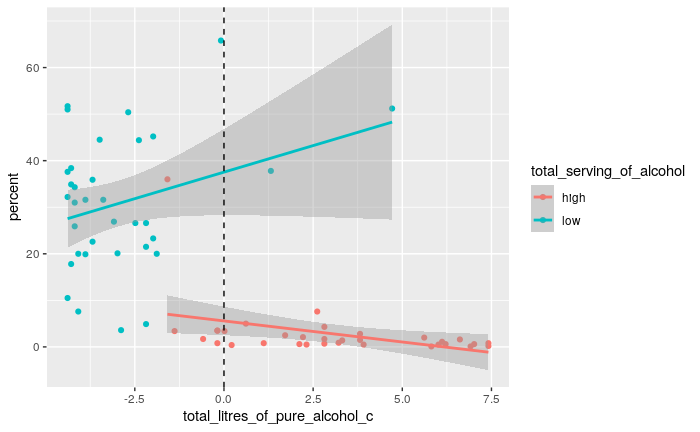

```r
dranks4 %>% select(percent, total_litres_of_pure_alcohol_c, total_serving_of_alcohol) %>% na.omit %>% ggplot(aes(total_litres_of_pure_alcohol_c, percent, color=total_serving_of_alcohol)) +
geom_point()+geom_smooth(method="lm") + geom_vline(xintercept=mean(dranks4$total_litres_of_pure_alcohol_c,na.rm=T),lty=2)
```

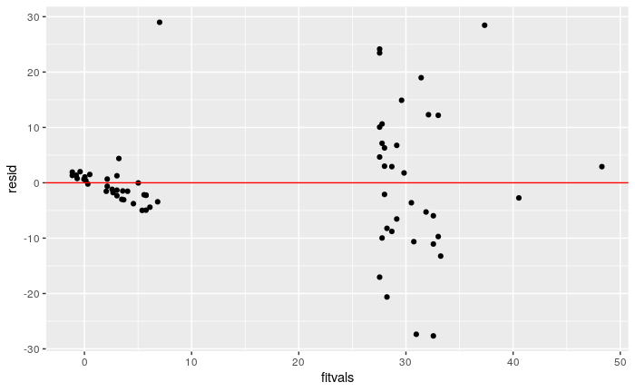

```r
resid<-fit$residuals
fitvals<-fit$fitted.values
ggplot()+geom_point(aes(fitvals,resid))+geom_hline(yintercept=0, color='red')
```

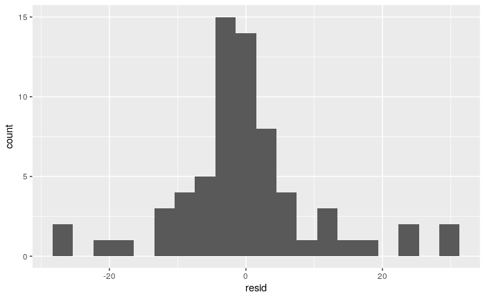

```r
ggplot()+geom_histogram(aes(resid), bins=20)
```

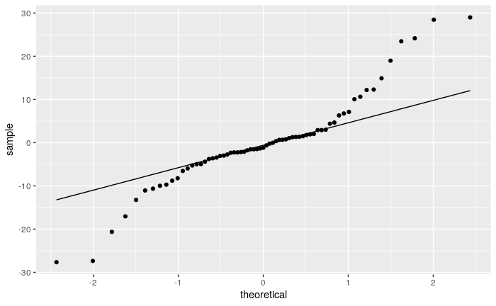

```r
ggplot()+geom_qq(aes(sample=resid))+geom_qq_line(aes(sample=resid))
```

*The intercept means that the Mean/predicted percent of cousin marriage for countries that consume high total servings of alcohol per person and with zero total_litres_of_pure_alcohol_c per person consumed is 5.57986.*

*total_litres_of_pure_alcohol_c means that for every 1-unit increase in total_litres_of_pure_alcohol_c, predicted percentage of cousin marriage goes down 0.90490 for this group.*

*total_litres_of_pure_alcohol_c:total_serving_of_alcohollow means that the slope of percentage of cousin marriage on total_litres_of_pure_alcohol_c for countries with low total serving of alcohol per person is 3.18395 greater than for countries with high total serving of alcohol per person.*

Check assumptions of linearity, normality, and homoskedasticity either graphically or using a hypothesis test (5) *The assumptions for normality, linearity, and homoskedasticity are not met, as shown by the graphs.*

#4-BOOTSTRAPPING

```r
#4-BOOTSTRAPPING
samp_distn <- replicate(5000, {
  boot_dat<- dranks4[sample(nrow(dranks4), replace = TRUE),]
  Reg1<- lm(fit, data=boot_dat)
  coef(Reg1)
})
samp_distn %>% t %>% as.data.frame %>% summarize_all(sd)
```

| (Intercept) | total_litres_of_pure_alcohol_c | total_serving_of_alcohollow | total_litres_of_pure_alcohol_c:total_serving_of_alcohollow |
| --- | --- | --- | --- |
| 2.639237 | 0.571453 | 6.758927 | 1.789869 |

```r
NA
```

```r
#5
library(ggplot2)
library(plotROC)
dranks6<-dranks5%>%mutate(y=ifelse(percent=="high",1,0))
dranks6
```

| country | percent | beer_servings | spirit_servings | wine_servings | total_litres_of_pure_alcohol | total_serving_of_alcohol | y |
| --- | --- | --- | --- | --- | --- | --- | --- |
| Burkina Faso | high | 25 | 7 | 7 | 4.3 | low | 1 |
| Kuwait | high | 0 | 0 | 0 | 0.0 | low | 1 |
| Nigeria | high | 42 | 5 | 2 | 9.1 | low | 1 |
| Pakistan | high | 0 | 0 | 0 | 0.0 | low | 1 |
| Sudan | high | 8 | 13 | 0 | 1.7 | low | 1 |
| Kyrgyzstan | high | 31 | 97 | 6 | 2.4 | low | 1 |
| Qatar | high | 1 | 42 | 7 | 0.9 | low | 1 |
| Bahrain | high | 42 | 63 | 7 | 2.0 | low | 1 |
| Saudi Arabia | high | 0 | 5 | 0 | 0.1 | low | 1 |
| Tanzania | high | 36 | 6 | 1 | 5.7 | low | 1 |

[output cut: 57 more lines]

```r
ogdranks<- glm(y~total_litres_of_pure_alcohol+wine_servings, data=dranks6, family= "binomial")
summary(ogdranks)
```

```
Call:
glm(formula = y ~ total_litres_of_pure_alcohol + wine_servings,
    family = "binomial", data = dranks6)

Deviance Residuals:
     Min        1Q    Median        3Q       Max
-2.15611  -0.21534  -0.00441   0.56915   2.27453

Coefficients:
                             Estimate Std. Error z value Pr(>|z|)
(Intercept)                   2.38128    0.61938   3.845 0.000121 ***
total_litres_of_pure_alcohol -0.53280    0.17019  -3.131 0.001745 **
wine_servings                -0.02064    0.02456  -0.840 0.400784
---
Signif. codes:  0 ‘***’ 0.001 ‘**’ 0.01 ‘*’ 0.05 ‘.’ 0.1 ‘ ’ 1

(Dispersion parameter for binomial family taken to be 1)

    Null deviance: 92.867  on 66  degrees of freedom
Residual deviance: 47.805  on 64  degrees of freedom
AIC: 53.805

Number of Fisher Scoring iterations: 8
```

```r
exp(coef(ogdranks))
```

```
                 (Intercept) total_litres_of_pure_alcohol                wine_servings
                  10.8187916                    0.5869573                    0.9795759
```

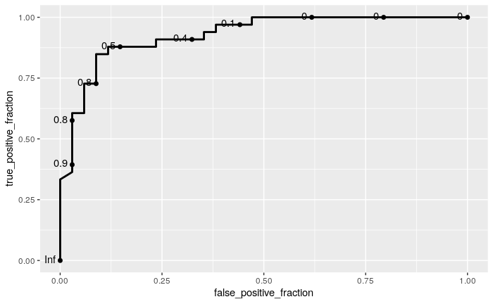

```r
dranks6$probs2<-predict(ogdranks, type = "response")
ggplot(dranks6)+geom_roc(aes(d=y, m=probs2))
```

```r
calc_auc(ggplot(dranks6)+geom_roc(aes(d=y, m=probs2)))
```

| PANEL | group | AUC |
| --- | --- | --- |
| 1 | -1 | 0.9273619 |

```r
probs2.1<-predict(ogdranks,type="response")
table(predict=as.numeric(probs2.1>.5),truth=dranks6$y)%>%addmargins
```

```
       truth
predict  0  1 Sum
    0   26  4  30
    1    8 29  37
    Sum 34 33  67
```

```r
accuracy <- (26+29)/67
accuracy
```

```
[1] 0.8208955
```

```r
sensitivity <-29/33
sensitivity
```

```
[1] 0.8787879
```

```r
specificity <-26/34
specificity
```

```
[1] 0.7647059
```

```r
precisison <- 29/37
precisison
```

```
[1] 0.7837838
```

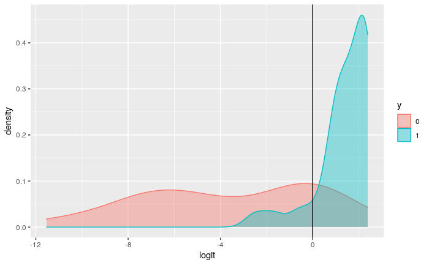

```r
dranks6$logit<-predict(ogdranks, type="link")
dranks6 %>% mutate(y=as.factor(y)) %>% ggplot()+geom_density(aes(logit, color=y, fill=y), alpha=.4)+geom_vline(xintercept = 0)+xlab("logit")
```

Interpret coefficient estimates in context (10) *The coefficients are intercept, total_litres_of_pure_alcohol, and wine_servings*

Compute and discuss the Accuracy, Sensitivity (TPR), Specificity (TNR), Precision (PPV), and AUC of your model (5) *The sensitivity is 0.8787879 , the specificity is 0.7647059, the precision is 0.7837838, the AUC is 0.9273619 , and the accuracy is 0.8208955.*

Generate an ROC curve (plot) and calculate AUC (either manually or with a package); interpret (5) *The AUC is 0.9273619, which is a high value for AUC. AUC is the the area under the ROC curve. This high AUC value means that the model is very good at distinguishing between countries of high and low cousin marriage percentages.*

```r
#6
######################################################################
dranks6<-dranks5%>%mutate(y=ifelse(percent=="high",1,0))
dranks7<-dranks6%>%dplyr::select(-country,-percent)
fit <- glm(y~(.), data=dranks7, family ="binomial")
```

```
glm.fit: fitted probabilities numerically 0 or 1 occurred
```

```r
fit
```

```
Call:  glm(formula = y ~ (.), family = "binomial", data = dranks7)

Coefficients:
                 (Intercept)                 beer_servings               spirit_servings                 wine_servings
                     0.34086                      -0.14454                      -0.04774                      -0.05577
total_litres_of_pure_alcohol   total_serving_of_alcohollow
                     3.58546                       3.74647

Degrees of Freedom: 66 Total (i.e. Null);  61 Residual
Null Deviance:      92.87
Residual Deviance: 16.15    AIC: 28.15
```

```r
probsX <- predict(fit, type ="response")
class_diag(probsX, dranks7$y)
```

| acc | sens | spec | ppv | auc |
| --- | --- | --- | --- | --- |
| 0.9701493 | 1 | 0.9411765 | 0.9428571 | 0.9910873 |

```r
table(predict=as.numeric(probsX>.5), truth=dranks7$y) %>% addmargins
```

```
       truth
predict  0  1 Sum
    0   32  0  32
    1    2 33  35
    Sum 34 33  67
```

```r
#######################################################################
set.seed(1234)
k=10
F<-FALSE
data<- dranks7[sample(nrow(dranks7)),]
folds<- cut(seq(1:nrow(dranks7)), breaks=k, labels=F)
diags<-NULL
for(i in 1:k){
  train<-data[folds!=i,]
  test<-data[folds==i,]
  truth<-test$y
  fit<-glm(y~.,data=train, family ="binomial")
  probs<-predict(fit,newdata=test,type="response")
  diags<-rbind(diags,class_diag(probs,truth))
}
```

[output not shown]

```r
diags %>% summarize_all(mean)
```

| acc | sens | spec | ppv | auc |
| --- | --- | --- | --- | --- |
| 0.9 | 0.89 | 0.9 | 0.96 | 0.9333333 |

```r
summary(fit)
```

```
Call:
glm(formula = y ~ ., family = "binomial", data = train)

Deviance Residuals:
     Min        1Q    Median        3Q       Max
-1.66714  -0.00007   0.00000   0.03524   1.37388

Coefficients:
                             Estimate Std. Error z value Pr(>|z|)
(Intercept)                    0.8668    21.5871   0.040    0.968
beer_servings                 -0.2737     0.2636  -1.038    0.299
spirit_servings               -0.1224     0.2219  -0.551    0.581
wine_servings                 -0.1000     0.1633  -0.613    0.540
total_litres_of_pure_alcohol   7.1887    12.1908   0.590    0.555
total_serving_of_alcohollow    7.2946    20.7379   0.352    0.725

(Dispersion parameter for binomial family taken to be 1)

    Null deviance: 82.9108  on 59  degrees of freedom
Residual deviance:  7.5342  on 54  degrees of freedom
AIC: 19.534

Number of Fisher Scoring iterations: 12
```

```r
########################################################################LASSO- are percenthigh and percentlow only ones then? therefore are no variables retained?
library(glmnet)
set.seed(1234)
x<- model.matrix(y~.+-1, data=dranks7)
y<- as.matrix(dranks7$y)
cv<-cv.glmnet(x,y,family="binomial")
lasso<-glmnet(x,y,family="binomial",lambda=cv$lambda.1se)
coef(lasso)
```

```
7 x 1 sparse Matrix of class "dgCMatrix"
                                        s0
(Intercept)                   1.779014e+00
beer_servings                -8.429880e-03
spirit_servings               .
wine_servings                 .
total_litres_of_pure_alcohol  .
total_serving_of_alcoholhigh -2.179692e+00
total_serving_of_alcohollow   3.470806e-14
```

```r
#########################################################################
set.seed(1234)
k=10
F<-FALSE
data <- dranks7 %>% sample_frac
folds <- ntile(1:nrow(data),n=10)
diags<-NULL
for(i in 1:k){
train <- data[folds!=i,]
test <- data[folds==i,]
truth <- test$y
fit<- glm(y~beer_servings+total_serving_of_alcohol,data=train, family="binomial") ####would there be nothing here then?######################
probs <- predict(fit, newdata=test, type="response")
diags<-rbind(diags,class_diag(probs,truth))
}
```

```
glm.fit: fitted probabilities numerically 0 or 1 occurred
```

```r
summarize_all(diags,mean)
```

| acc | sens | spec | ppv | auc |
| --- | --- | --- | --- | --- |
| 0.9404762 | 0.98 | 0.8166667 | 0.9457143 | 0.9583333 |

Perform 10-fold (or repeated random sub-sampling) CV with the same model and report average out-of-sample classification diagnostics (Accuracy, Sensitivity, Specificity, Precision, and AUC); interpret AUC and compare with the in-sample metrics (10)

Perform 10-fold CV using only the variables lasso selected: compare model’s out-of-sample AUC to that of your logistic regressions above (5)